# Analyzing historic hurricane tracks - Part 1/3

Hurricanes are large swirling storms that produce winds of speeds `74` miles per hour (`119` kmph) or higher. When hurricanes make a landfall, they produce heavy rainfall, cause storm surges and intense flooding. Often hurricanes strike places that are dense in population, causing devastating amounts of death and destruction throughout the world.

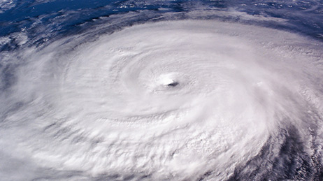

## Part 1 - prepare hurricane data

This notebook covers part 1 of this study. In this notebook we download data from NCEI portal, do extenstive pre-processing in the form of clearing headers, merging redundant columns and aggregate the observations into hurricane tracks.

# **Table of Contents**

## Download hurricane data from NCEI FTP portal

The [National Centers for Environmental Information](https://www.ncdc.noaa.gov/), formerly [National Climatic Data Center](https://www.ncdc.noaa.gov/) shares the historic hurricane track datasets at ftp://eclipse.ncdc.noaa.gov/pub/ibtracs/v03r09/all/csv/. We use the `ftplib` Python library to login in and download these datasets.

```python
# imports for downloading data from FTP site
import os
from ftplib import FTP

# imports to process data using DASK
from dask import delayed
import dask.dataframe as ddf

# imports for data analysis and visualization
import pandas as pd
import matplotlib.pyplot as plt
%matplotlib inline

# imports to perform spatial aggregation using ArcGIS GeoAnalytics server
from arcgis.gis import GIS
from arcgis.geoanalytics import get_datastores
from arcgis.geoanalytics.summarize_data import reconstruct_tracks
import arcgis
```

Establish an anonymous connection to FTP site

```python
conn = FTP(host='eclipse.ncdc.noaa.gov')
conn.login()
```

```
'230 Anonymous access granted, restrictions apply'
```

Change directory to folder contianing the hurricane files. List the files

```python
conn.cwd('/pub/ibtracs/v03r10/all/csv/year/')
file_list = conn.nlst()
len(file_list)
```

```
176
```

Print the top 10 items

```python
file_list[:10]
```

```
['Year.1842.ibtracs_all.v03r10.csv',
 'Year.1843.ibtracs_all.v03r10.csv',
 'Year.1844.ibtracs_all.v03r10.csv',
 'Year.1845.ibtracs_all.v03r10.csv',
 'Year.1846.ibtracs_all.v03r10.csv',
 'Year.1847.ibtracs_all.v03r10.csv',
 'Year.1848.ibtracs_all.v03r10.csv',
 'Year.1849.ibtracs_all.v03r10.csv',
 'Year.1850.ibtracs_all.v03r10.csv',
 'Year.1851.ibtracs_all.v03r10.csv']
```

### Download each file into `hurricanes_raw` directory

```python
data_dir = './me'
```

```python
if 'hurricanes_raw' not in os.listdir(data_dir):
    os.mkdir(os.path.join(data_dir,'hurricanes_raw'))

hurricane_raw_dir = os.path.join(data_dir,'hurricanes_raw')
os.listdir(data_dir)
```

```
['Allstorms.ibtracs_all.v03r09.csv',
 'hurricanes_raw',
 '.nb_auth_file',
 'Allstorms.ibtracs_all.v03r09.csv.gz']
```

```python
%%time
file_path = hurricane_raw_dir
for file in file_list:
    with open(os.path.join(file_path, file), 'wb') as file_handle:
        try:
            conn.retrbinary('RETR ' + file, file_handle.write, 1024)
            print(f'Downloaded {file}')

        except Exception as download_ex:
            print(f'Error downloading {file} + {str(download_ex)}')
```

```
Downloaded Year.1842.ibtracs_all.v03r10.csv
Downloaded Year.1843.ibtracs_all.v03r10.csv
Downloaded Year.1844.ibtracs_all.v03r10.csv
Downloaded Year.1845.ibtracs_all.v03r10.csv
....Downloaded Year.2015.ibtracs_all.v03r10.csv
Downloaded Year.2016.ibtracs_all.v03r10.csv
Downloaded Year.2017.ibtracs_all.v03r10.csv
CPU times: user 8.63 s, sys: 12.1 s, total: 20.8 s
Wall time: 12min 5s
```

## Process CSV files by removing header rows

The CSV files have multiple header rows. Let us start by processing one of the files as an example

```python
import pandas as pd
```

```python
csv_path = os.path.join(hurricane_raw_dir,'Year.2017.ibtracs_all.v03r10.csv')
```

```python
df = pd.read_csv(csv_path)
df.head()
```

|  |  |  |  |  |  |  |  |  |  |  |  |  |  |  |  |  |  |  |  |  |  |  |  |  |  |  |  |  |  | … |
| --- | --- | --- | --- | --- | --- | --- | --- | --- | --- | --- | --- | --- | --- | --- | --- | --- | --- | --- | --- | --- | --- | --- | --- | --- | --- | --- | --- | --- | --- | --- |
| Serial_Num | Season | Num | Basin | Sub_basin | Name | ISO_time | Nature | Latitude | Longitude | Wind(WMO) | Pres(WMO) | Center | Wind(WMO) Percentile | Pres(WMO) Percentile | Track_type | Latitude_for_mapping | Longitude_for_mapping | Current Basin | hurdat_atl_lat | hurdat_atl_lon | hurdat_atl_grade | hurdat_atl_wind | hurdat_atl_pres | td9636_lat | td9636_lon | td9636_grade | td9636_wind | td9636_pres | reunion_lat | … |
| NaN | Year | # | BB | BB | NaN | YYYY-MM-DD HH:MM:SS | NaN | deg_north | deg_east | kt | mb | NaN | % | % | NaN | degrees_north | degrees_east | NaN | deg_north | deg_east |  | kt | mb | deg_north | deg_east |  | kt | mb | deg_north | … |
| 1874011S14064 | 1874 | 01 | SI | MM | XXXX874148 | 1874-01-11 06:00:00 | NR | -13.70 | 63.90 | 0.0 | 0.0 | reunion | -100.000 | -100.000 | main | -13.70 | 63.90 | SI | -999.0 | -999.0 | -999.0 | -999.0 | -999.0 | -999.0 | -999.0 | -999.0 | -999.0 | -999.0 | -13.7 | … |
|  |  |  |  |  |  | 1874-01-11 12:00:00 | NR | -999. | -999. | -999. | -999. | NaN | -999. | -999. | main | -13.75 | 63.86 | SI | -999.0 | -999.0 | -999.0 | -999.0 | -999.0 | -999.0 | -999.0 | -999.0 | -999.0 | -999.0 | -13.7 | … |
|  |  |  |  |  |  | 1874-01-11 18:00:00 | NR | -999. | -999. | -999. | -999. | NaN | -999. | -999. | main | -13.88 | 63.77 | SI | -999.0 | -999.0 | -999.0 | -999.0 | -999.0 | -999.0 | -999.0 | -999.0 | -999.0 | -999.0 | -13.9 | … |

The input looks mangled. This is because the file's row `1` has a header that pandas fails to read. So let us skip that row

```python
df = pd.read_csv(csv_path, skiprows=1)
df.head()
```

|  | Serial_Num | Season | Num | Basin | Sub_basin | Name | ISO_time | Nature | Latitude | Longitude | ... | jtwc_??_wrad34_rad3 | jtwc_??_wrad34_rad4 | jtwc_??_wrad50_rad1 | jtwc_??_wrad50_rad2 | jtwc_??_wrad50_rad3 | jtwc_??_wrad50_rad4 | jtwc_??_wrad64_rad1 | jtwc_??_wrad64_rad2 | jtwc_??_wrad64_rad3 | jtwc_??_wrad64_rad4 |
| --- | --- | --- | --- | --- | --- | --- | --- | --- | --- | --- | --- | --- | --- | --- | --- | --- | --- | --- | --- | --- | --- |
| 0 | NaN | Year | # | BB | BB | NaN | YYYY-MM-DD HH:MM:SS | NaN | deg_north | deg_east | ... | nmile | nmile | nmile | nmile | nmile | nmile | nmile | nmile | nmile | nmile |
| 1 | 1874011S14064 | 1874 | 01 | SI | MM | XXXX874148 | 1874-01-11 06:00:00 | NR | -13.70 | 63.90 | ... | -999.000 | -999.000 | -999.000 | -999.000 | -999.000 | -999.000 | -999.000 | -999.000 | -999.000 | -999.000 |
| 2 | 1874011S14064 | 1874 | 01 | SI | MM | XXXX874148 | 1874-01-11 12:00:00 | NR | -999. | -999. | ... | -999.000 | -999.000 | -999.000 | -999.000 | -999.000 | -999.000 | -999.000 | -999.000 | -999.000 | -999.000 |
| 3 | 1874011S14064 | 1874 | 01 | SI | MM | XXXX874148 | 1874-01-11 18:00:00 | NR | -999. | -999. | ... | -999.000 | -999.000 | -999.000 | -999.000 | -999.000 | -999.000 | -999.000 | -999.000 | -999.000 | -999.000 |
| 4 | 1874011S14064 | 1874 | 01 | SI | MM | XXXX874148 | 1874-01-12 00:00:00 | NR | -999. | -999. | ... | -999.000 | -999.000 | -999.000 | -999.000 | -999.000 | -999.000 | -999.000 | -999.000 | -999.000 | -999.000 |

5 rows × 200 columns

A little better. But the file's 3rd row is also a header. Let us drop that row

```python
df.drop(labels=0, axis=0, inplace=True)
df.head()
```

|  | Serial_Num | Season | Num | Basin | Sub_basin | Name | ISO_time | Nature | Latitude | Longitude | ... | jtwc_??_wrad34_rad3 | jtwc_??_wrad34_rad4 | jtwc_??_wrad50_rad1 | jtwc_??_wrad50_rad2 | jtwc_??_wrad50_rad3 | jtwc_??_wrad50_rad4 | jtwc_??_wrad64_rad1 | jtwc_??_wrad64_rad2 | jtwc_??_wrad64_rad3 | jtwc_??_wrad64_rad4 |
| --- | --- | --- | --- | --- | --- | --- | --- | --- | --- | --- | --- | --- | --- | --- | --- | --- | --- | --- | --- | --- | --- |
| 1 | 1874011S14064 | 1874 | 01 | SI | MM | XXXX874148 | 1874-01-11 06:00:00 | NR | -13.70 | 63.90 | ... | -999.000 | -999.000 | -999.000 | -999.000 | -999.000 | -999.000 | -999.000 | -999.000 | -999.000 | -999.000 |
| 2 | 1874011S14064 | 1874 | 01 | SI | MM | XXXX874148 | 1874-01-11 12:00:00 | NR | -999. | -999. | ... | -999.000 | -999.000 | -999.000 | -999.000 | -999.000 | -999.000 | -999.000 | -999.000 | -999.000 | -999.000 |
| 3 | 1874011S14064 | 1874 | 01 | SI | MM | XXXX874148 | 1874-01-11 18:00:00 | NR | -999. | -999. | ... | -999.000 | -999.000 | -999.000 | -999.000 | -999.000 | -999.000 | -999.000 | -999.000 | -999.000 | -999.000 |
| 4 | 1874011S14064 | 1874 | 01 | SI | MM | XXXX874148 | 1874-01-12 00:00:00 | NR | -999. | -999. | ... | -999.000 | -999.000 | -999.000 | -999.000 | -999.000 | -999.000 | -999.000 | -999.000 | -999.000 | -999.000 |
| 5 | 1874011S14064 | 1874 | 01 | SI | MM | XXXX874148 | 1874-01-12 06:00:00 | NR | -14.80 | 63.30 | ... | -999.000 | -999.000 | -999.000 | -999.000 | -999.000 | -999.000 | -999.000 | -999.000 | -999.000 | -999.000 |

5 rows × 200 columns

### Automate across all files

Now we need to repeat the above cleaning steps across all CSV files. In the steps below, we will read all CSV files, drop the headers and write to disk. This step is necessary as it will ease subsequent processing using the DASK library.

```python
%%time
file_path = hurricane_raw_dir
num_records = {}
for file in file_list:
    df = pd.read_csv(os.path.join(file_path, file), skiprows=1)
    num_records[str(file.split('.')[1])] = df.shape[0]

    df.drop(labels=0, axis=0, inplace=True)
    df.to_csv(os.path.join(file_path, file))
    print(f'Processed {file}')
```

```
Processed Year.1842.ibtracs_all.v03r10.csv
Processed Year.1843.ibtracs_all.v03r10.csv
Processed Year.1844.ibtracs_all.v03r10.csv
Processed Year.1845.ibtracs_all.v03r10.csv
...Processed Year.2013.ibtracs_all.v03r10.csv
Processed Year.2014.ibtracs_all.v03r10.csv
Processed Year.2015.ibtracs_all.v03r10.csv
Processed Year.2016.ibtracs_all.v03r10.csv
Processed Year.2017.ibtracs_all.v03r10.csv
CPU times: user 36.4 s, sys: 3.39 s, total: 39.8 s
Wall time: 46.8 s
```

# Cleaning hurricane observations with Dask

The data collected from NOAA NCDC source is just too large to clean with Pandas or Excel. With `350,000 x 200` in dense matrix, this data is larger than memory for a normal computer. Hence traditional packages such as Pandas cannot be used as they expect data to fit fully in memory.

Thus, in this part of the study, we use **[Dask](https://dask.org/)**, a distributed data analysis library. Functionally, Dask provides a `DataFrame` object that behaves similar to a traditional pandas `DataFrame` object. You can perform slicing, dicing, exploration on them. However transformative operations on the `DataFrame` get queued and are operated only when necessary. When executed, Dask will read data in chunks, distribute it to workers (be it cores on a single machine or multiple machines in a cluster set up) and collect the data back for you. Thus, DASK allows you to work with any larger than memory dataset as it performs operations on chunks of it, in a distributed manner.

## Read input CSV data

As mentioned earlier DASK allows you to work with larger than memory datasets. These datasets can reside as one large file or as multiple files in a folder. For latter, DASK allows you to just specify the folder containing the datasets as input. In turn, it provides you a single `DataFrame` object that represents all your datasets combined together. The operations you perform on this `DataFrame` get queued and executed only when necessary.

```python
fld_path = hurricane_raw_dir
csv_path = os.path.join(fld_path,'*.csv')
```

Preemptively, specify the assortment of values that should be treated as null values.

```python
%%time
table_na_values=['-999.','-999','-999.000', '-1', '-1.0','0','0.0']
full_df = ddf.read_csv(csv_path, na_values=table_na_values, dtype={'Center': 'object'})
```

```
CPU times: user 1.26 s, sys: 17.6 ms, total: 1.28 s
Wall time: 1.29 s
```

You can query the top few (or bottom few) records as you do on a regular Pandas `DataFrame` object.

```python
full_df.head()
```

|  | Unnamed: 0 | Serial_Num | Season | Num | Basin | Sub_basin | Name | ISO_time | Nature | Latitude | ... | jtwc_??_wrad34_rad3 | jtwc_??_wrad34_rad4 | jtwc_??_wrad50_rad1 | jtwc_??_wrad50_rad2 | jtwc_??_wrad50_rad3 | jtwc_??_wrad50_rad4 | jtwc_??_wrad64_rad1 | jtwc_??_wrad64_rad2 | jtwc_??_wrad64_rad3 | jtwc_??_wrad64_rad4 |
| --- | --- | --- | --- | --- | --- | --- | --- | --- | --- | --- | --- | --- | --- | --- | --- | --- | --- | --- | --- | --- | --- |
| 0 | 1 | 1842298N11080 | 1842 | 1 | NI | BB | NOT NAMED | 1842-10-25 06:00:00 | NR | NaN | ... | NaN | NaN | NaN | NaN | NaN | NaN | NaN | NaN | NaN | NaN |
| 1 | 2 | 1842298N11080 | 1842 | 1 | NI | BB | NOT NAMED | 1842-10-25 12:00:00 | NR | NaN | ... | NaN | NaN | NaN | NaN | NaN | NaN | NaN | NaN | NaN | NaN |
| 2 | 3 | 1842298N11080 | 1842 | 1 | NI | AS | NOT NAMED | 1842-10-25 18:00:00 | NR | NaN | ... | NaN | NaN | NaN | NaN | NaN | NaN | NaN | NaN | NaN | NaN |
| 3 | 4 | 1842298N11080 | 1842 | 1 | NI | AS | NOT NAMED | 1842-10-26 00:00:00 | NR | NaN | ... | NaN | NaN | NaN | NaN | NaN | NaN | NaN | NaN | NaN | NaN |
| 4 | 5 | 1842298N11080 | 1842 | 1 | NI | AS | NOT NAMED | 1842-10-26 06:00:00 | NR | NaN | ... | NaN | NaN | NaN | NaN | NaN | NaN | NaN | NaN | NaN | NaN |

5 rows × 201 columns

Drop the first, duplicate index column

```python
full_df = full_df.drop(labels=['Unnamed: 0'], axis=1)
```

```python
all_columns=list(full_df.columns)
len(all_columns)
```

```
200
```

This dataset has `200` columns. Not all are unique as you can see from the print below:

```python
from pprint import pprint
pprint(all_columns, compact=True, width=100)
```

```
['Serial_Num', 'Season', 'Num', 'Basin', 'Sub_basin', 'Name', 'ISO_time', 'Nature', 'Latitude',
 'Longitude', 'Wind(WMO)', 'Pres(WMO)', 'Center', 'Wind(WMO) Percentile', 'Pres(WMO) Percentile',
 'Track_type', 'Latitude_for_mapping', 'Longitude_for_mapping', 'Current Basin', 'hurdat_atl_lat',
 'hurdat_atl_lon', 'hurdat_atl_grade', 'hurdat_atl_wind', 'hurdat_atl_pres', 'td9636_lat',
 'td9636_lon', 'td9636_grade', 'td9636_wind', 'td9636_pres', 'reunion_lat', 'reunion_lon',
 'reunion_grade', 'reunion_wind', 'reunion_pres', 'atcf_lat', 'atcf_lon', 'atcf_grade', 'atcf_wind',
 'atcf_pres', 'mlc_natl_lat', 'mlc_natl_lon', 'mlc_natl_grade', 'mlc_natl_wind', 'mlc_natl_pres',
 'ds824_sh_lat', 'ds824_sh_lon', 'ds824_sh_grade', 'ds824_sh_wind', 'ds824_sh_pres', 'ds824_ni_lat',
 'ds824_ni_lon', 'ds824_ni_grade', 'ds824_ni_wind', 'ds824_ni_pres', 'bom_lat', 'bom_lon',
 'bom_grade', 'bom_wind', 'bom_pres', 'ds824_au_lat', 'ds824_au_lon', 'ds824_au_grade',
 'ds824_au_wind', 'ds824_au_pres', 'jtwc_sh_lat', 'jtwc_sh_lon', 'jtwc_sh_grade', 'jtwc_sh_wind',
 'jtwc_sh_pres', 'jtwc_wp_lat', 'jtwc_wp_lon', 'jtwc_wp_grade', 'jtwc_wp_wind', 'jtwc_wp_pres',
 'td9635_lat', 'td9635_lon', 'td9635_grade', 'td9635_wind', 'td9635_pres', 'ds824_wp_lat',
 'ds824_wp_lon', 'ds824_wp_grade', 'ds824_wp_wind', 'ds824_wp_pres', 'jtwc_io_lat', 'jtwc_io_lon',
 'jtwc_io_grade', 'jtwc_io_wind', 'jtwc_io_pres', 'cma_lat', 'cma_lon', 'cma_grade', 'cma_wind',
 'cma_pres', 'hurdat_epa_lat', 'hurdat_epa_lon', 'hurdat_epa_grade', 'hurdat_epa_wind',
 'hurdat_epa_pres', 'jtwc_ep_lat', 'jtwc_ep_lon', 'jtwc_ep_grade', 'jtwc_ep_wind', 'jtwc_ep_pres',
 'ds824_ep_lat', 'ds824_ep_lon', 'ds824_ep_grade', 'ds824_ep_wind', 'ds824_ep_pres', 'jtwc_cp_lat',
 'jtwc_cp_lon', 'jtwc_cp_grade', 'jtwc_cp_wind', 'jtwc_cp_pres', 'tokyo_lat', 'tokyo_lon',
 'tokyo_grade', 'tokyo_wind', 'tokyo_pres', 'neumann_lat', 'neumann_lon', 'neumann_grade',
 'neumann_wind', 'neumann_pres', 'hko_lat', 'hko_lon', 'hko_grade', 'hko_wind', 'hko_pres',
 'cphc_lat', 'cphc_lon', 'cphc_grade', 'cphc_wind', 'cphc_pres', 'wellington_lat', 'wellington_lon',
 'wellington_grade', 'wellington_wind', 'wellington_pres', 'newdelhi_lat', 'newdelhi_lon',
 'newdelhi_grade', 'newdelhi_wind', 'newdelhi_pres', 'nadi_lat', 'nadi_lon', 'nadi_grade',
 'nadi_wind', 'nadi_pres', 'reunion_rmw', 'reunion_wind_radii_1_ne', 'reunion_wind_radii_1_se',
 'reunion_wind_radii_1_sw', 'reunion_wind_radii_1_nw', 'reunion_wind_radii_2_ne',
 'reunion_wind_radii_2_se', 'reunion_wind_radii_2_sw', 'reunion_wind_radii_2_nw',
 'bom_mn_hurr_xtnt', 'bom_mn_gale_xtnt', 'bom_mn_eye_diam', 'bom_roci', 'atcf_rmw', 'atcf_poci',
 'atcf_roci', 'atcf_eye', 'atcf_wrad34_rad1', 'atcf_wrad34_rad2', 'atcf_wrad34_rad3',
 'atcf_wrad34_rad4', 'atcf_wrad50_rad1', 'atcf_wrad50_rad2', 'atcf_wrad50_rad3', 'atcf_wrad50_rad4',
 'atcf_wrad64_rad1', 'atcf_wrad64_rad2', 'atcf_wrad64_rad3', 'atcf_wrad64_rad4', 'tokyo_dir50',
 'tokyo_long50', 'tokyo_short50', 'tokyo_dir30', 'tokyo_long30', 'tokyo_short30', 'jtwc_??_rmw',
 'jtwc_??_poci', 'jtwc_??_roci', 'jtwc_??_eye', 'jtwc_??_wrad34_rad1', 'jtwc_??_wrad34_rad2',
 'jtwc_??_wrad34_rad3', 'jtwc_??_wrad34_rad4', 'jtwc_??_wrad50_rad1', 'jtwc_??_wrad50_rad2',
 'jtwc_??_wrad50_rad3', 'jtwc_??_wrad50_rad4', 'jtwc_??_wrad64_rad1', 'jtwc_??_wrad64_rad2',
 'jtwc_??_wrad64_rad3', 'jtwc_??_wrad64_rad4']
```

Reading the metadata from NOAA NCDC site, we find sensor measurements get unique columns if they are collected by a different agency. Thus we find multiple **pressure**, **wind speed**, **latitude**, **longitude**, etc. columns with different suffixes and prefixes. Data is sparse as it gets distributed between these columns. For our geospatial analysis, it suffices if we can merge these columns together and get location information from the co-ordinates.

## Merge all location columns

Below we prototype merging location columns. If this succeeds, we will proceed to merge all remaining columns

```python
lat_columns = [x for x in all_columns if 'lat' in x.lower()]
lon_columns = [x for x in all_columns if 'lon' in x.lower()]
for x in zip(lat_columns, lon_columns):
    print(x)
```

```
('Latitude', 'Longitude')
('Latitude_for_mapping', 'Longitude_for_mapping')
('hurdat_atl_lat', 'hurdat_atl_lon')
('td9636_lat', 'td9636_lon')
('reunion_lat', 'reunion_lon')
('atcf_lat', 'atcf_lon')
('mlc_natl_lat', 'mlc_natl_lon')
('ds824_sh_lat', 'ds824_sh_lon')
('ds824_ni_lat', 'ds824_ni_lon')
('bom_lat', 'bom_lon')
('ds824_au_lat', 'ds824_au_lon')
('jtwc_sh_lat', 'jtwc_sh_lon')
('jtwc_wp_lat', 'jtwc_wp_lon')
('td9635_lat', 'td9635_lon')
('ds824_wp_lat', 'ds824_wp_lon')
('jtwc_io_lat', 'jtwc_io_lon')
('cma_lat', 'cma_lon')
('hurdat_epa_lat', 'hurdat_epa_lon')
('jtwc_ep_lat', 'jtwc_ep_lon')
('ds824_ep_lat', 'ds824_ep_lon')
('jtwc_cp_lat', 'jtwc_cp_lon')
('tokyo_lat', 'tokyo_lon')
('neumann_lat', 'neumann_lon')
('hko_lat', 'hko_lon')
('cphc_lat', 'cphc_lon')
('wellington_lat', 'wellington_lon')
('newdelhi_lat', 'newdelhi_lon')
('nadi_lat', 'nadi_lon')
```

In this dataset, if data is collected by 1 agency, the corresponding duplicate columns from other agencies are empty. However there may be exceptions. Hence we define a custom function that will pick median value for a row, from a given list of columns. This way, we can consolidate latitude / longitude information from all the agencies.

```python
def pick_median_value(row, col_list):
    return row[col_list].median()
```

```python
%%time
full_df['latitude_merged'] = full_df.apply(pick_median_value, axis=1,
                                          col_list = lat_columns)
```

```
CPU times: user 56.9 ms, sys: 5.31 ms, total: 62.2 ms
Wall time: 58.3 ms
```

```python
%%time
full_df['longitude_merged'] = full_df.apply(pick_median_value, axis=1,
                                          col_list = lon_columns)
```

```
CPU times: user 58.3 ms, sys: 5.43 ms, total: 63.7 ms
Wall time: 59.1 ms
```

With `dask`, the above operation was delayed and stored in a queue. It has not been evaluated yet. Next, let us evaluate for `5` records and print output. If results look good, we will merge all remaining related columns together.

```python
%%time
full_df.head(5)
```

```
CPU times: user 137 ms, sys: 6.17 ms, total: 143 ms
Wall time: 141 ms
```

|  | Serial_Num | Season | Num | Basin | Sub_basin | Name | ISO_time | Nature | Latitude | Longitude | ... | jtwc_??_wrad50_rad1 | jtwc_??_wrad50_rad2 | jtwc_??_wrad50_rad3 | jtwc_??_wrad50_rad4 | jtwc_??_wrad64_rad1 | jtwc_??_wrad64_rad2 | jtwc_??_wrad64_rad3 | jtwc_??_wrad64_rad4 | latitude_merged | longitude_merged |
| --- | --- | --- | --- | --- | --- | --- | --- | --- | --- | --- | --- | --- | --- | --- | --- | --- | --- | --- | --- | --- | --- |
| 0 | 1842298N11080 | 1842 | 1 | NI | BB | NOT NAMED | 1842-10-25 06:00:00 | NR | NaN | NaN | ... | NaN | NaN | NaN | NaN | NaN | NaN | NaN | NaN | 10.885 | 79.815 |
| 1 | 1842298N11080 | 1842 | 1 | NI | BB | NOT NAMED | 1842-10-25 12:00:00 | NR | NaN | NaN | ... | NaN | NaN | NaN | NaN | NaN | NaN | NaN | NaN | 10.810 | 78.890 |
| 2 | 1842298N11080 | 1842 | 1 | NI | AS | NOT NAMED | 1842-10-25 18:00:00 | NR | NaN | NaN | ... | NaN | NaN | NaN | NaN | NaN | NaN | NaN | NaN | 10.795 | 77.910 |
| 3 | 1842298N11080 | 1842 | 1 | NI | AS | NOT NAMED | 1842-10-26 00:00:00 | NR | NaN | NaN | ... | NaN | NaN | NaN | NaN | NaN | NaN | NaN | NaN | 10.795 | 76.915 |
| 4 | 1842298N11080 | 1842 | 1 | NI | AS | NOT NAMED | 1842-10-26 06:00:00 | NR | NaN | NaN | ... | NaN | NaN | NaN | NaN | NaN | NaN | NaN | NaN | 10.805 | 75.820 |

5 rows × 202 columns

The results look good. Two additional columns(`latitude_merged`, `longitude_merged`) have been added. Thus by merging related columns, the redundant sparse columns can be removed and thereby simplifying the dimension of the input dataset.

Now that this prototype looks good, we will proceed by identifying the lists of remaining columns that are redundant and can be merged.

## Merge similar columns

To keep track of which columns have been accounted for, we will duplicate the `all_columns` list and remove ones that we have identified.

```python
from copy import deepcopy
columns_tracker = deepcopy(all_columns)
len(columns_tracker)
```

```
200
```

From the `columns_tracker` list, let us remove the redundant columns we already identified for location columns:

```python
columns_tracker = [x for x in columns_tracker if x not in lat_columns]
columns_tracker = [x for x in columns_tracker if x not in lon_columns]
len(columns_tracker)
```

```
142
```

Thus, we have reduced the number of columns from `200` to `142`. We will progressively reduce this while retaining key information.

### Merge wind columns

Wind, pressure, grade are some of the meteorological observations this dataset contains. To start off, let us identify the wind columns:

```python
# pick all columns that have 'wind' in name
wind_columns = [x for x in columns_tracker if 'wind' in x.lower()]

# based on metadata doc, we decide to eliminate percentile and wind distance columns
columns_to_eliminate = [x for x in wind_columns if 'radii' in x or 'percentile' in x.lower()]

# trim wind_columns by removing the ones we need to eliminate
wind_columns = [x for x in wind_columns if x not in columns_to_eliminate]
wind_columns
```

```
['Wind(WMO)',
 'hurdat_atl_wind',
 'td9636_wind',
 'reunion_wind',
 'atcf_wind',
 'mlc_natl_wind',
 'ds824_sh_wind',
 'ds824_ni_wind',
 'bom_wind',
 'ds824_au_wind',
 'jtwc_sh_wind',
 'jtwc_wp_wind',
 'td9635_wind',
 'ds824_wp_wind',
 'jtwc_io_wind',
 'cma_wind',
 'hurdat_epa_wind',
 'jtwc_ep_wind',
 'ds824_ep_wind',
 'jtwc_cp_wind',
 'tokyo_wind',
 'neumann_wind',
 'hko_wind',
 'cphc_wind',
 'wellington_wind',
 'newdelhi_wind',
 'nadi_wind']
```

```python
%%time
full_df['wind_merged'] = full_df.apply(pick_median_value, axis=1,
                                          col_list = wind_columns)
```

```
CPU times: user 56.7 ms, sys: 4.92 ms, total: 61.6 ms
Wall time: 57.6 ms
```

#### Merge pressure columns

We proceed to identify all `pressure` columns. But before that, we update the `columns_tracker` list by removing those we identified for wind:

```python
columns_tracker = [x for x in columns_tracker if x not in wind_columns]
columns_tracker = [x for x in columns_tracker if x not in columns_to_eliminate]
len(columns_tracker)
```

```
106
```

```python
# pick all columns that have 'pres' in name
pressure_columns = [x for x in columns_tracker if 'pres' in x.lower()]

# from metadata, we eliminate percentile and pres distance columns
if columns_to_eliminate:
    columns_to_eliminate.extend([x for x in pressure_columns if 'radii' in x or 'percentile' in x.lower()])
else:
    columns_to_eliminate = [x for x in pressure_columns if 'radii' in x or 'percentile' in x.lower()]

# trim wind_columns by removing the ones we need to eliminate
pressure_columns = [x for x in pressure_columns if x not in columns_to_eliminate]
pressure_columns
```

```
['Pres(WMO)',
 'hurdat_atl_pres',
 'td9636_pres',
 'reunion_pres',
 'atcf_pres',
 'mlc_natl_pres',
 'ds824_sh_pres',
 'ds824_ni_pres',
 'bom_pres',
 'ds824_au_pres',
 'jtwc_sh_pres',
 'jtwc_wp_pres',
 'td9635_pres',
 'ds824_wp_pres',
 'jtwc_io_pres',
 'cma_pres',
 'hurdat_epa_pres',
 'jtwc_ep_pres',
 'ds824_ep_pres',
 'jtwc_cp_pres',
 'tokyo_pres',
 'neumann_pres',
 'hko_pres',
 'cphc_pres',
 'wellington_pres',
 'newdelhi_pres',
 'nadi_pres']
```

```python
%%time
full_df['pressure_merged'] = full_df.apply(pick_median_value, axis=1,
                                          col_list = pressure_columns)
```

```
CPU times: user 122 ms, sys: 5.33 ms, total: 127 ms
Wall time: 123 ms
```

#### Merge grade columns

```python
columns_tracker = [x for x in columns_tracker if x not in pressure_columns]
columns_tracker = [x for x in columns_tracker if x not in columns_to_eliminate]
len(columns_tracker)
```

```
78
```

Notice the length of `columns_tracker` is reducing progressively as we identify redundant columns.

```python
# pick all columns that have 'grade' in name
grade_columns = [x for x in columns_tracker if 'grade' in x.lower()]
grade_columns
```

```
['hurdat_atl_grade',
 'td9636_grade',
 'reunion_grade',
 'atcf_grade',
 'mlc_natl_grade',
 'ds824_sh_grade',
 'ds824_ni_grade',
 'bom_grade',
 'ds824_au_grade',
 'jtwc_sh_grade',
 'jtwc_wp_grade',
 'td9635_grade',
 'ds824_wp_grade',
 'jtwc_io_grade',
 'cma_grade',
 'hurdat_epa_grade',
 'jtwc_ep_grade',
 'ds824_ep_grade',
 'jtwc_cp_grade',
 'tokyo_grade',
 'neumann_grade',
 'hko_grade',
 'cphc_grade',
 'wellington_grade',
 'newdelhi_grade',
 'nadi_grade']
```

```python
%%time
full_df['grade_merged'] = full_df.apply(pick_median_value, axis=1,
                                          col_list = grade_columns)
```

```
CPU times: user 54.9 ms, sys: 5.59 ms, total: 60.5 ms
Wall time: 56.4 ms
```

#### Merge eye diameter columns

```python
columns_tracker = [x for x in columns_tracker if x not in grade_columns]
len(columns_tracker)
```

```
52
```

```python
# pick all columns that have 'eye' in name
eye_dia_columns = [x for x in columns_tracker if 'eye' in x.lower()]
eye_dia_columns
```

```
['bom_mn_eye_diam', 'atcf_eye', 'jtwc_??_eye']
```

```python
%%time
full_df['eye_dia_merged'] = full_df.apply(pick_median_value, axis=1,
                                          col_list = eye_dia_columns)
```

```
CPU times: user 53.6 ms, sys: 4.74 ms, total: 58.4 ms
Wall time: 54.8 ms
```

### Identify remaining redundant columns

```python
columns_tracker = [x for x in columns_tracker if x not in eye_dia_columns]
len(columns_tracker)
```

```
49
```

We are down to `49` columns, let us visualize what those look like.

```python
pprint(columns_tracker, width=119, compact=True)
```

```
['Serial_Num', 'Season', 'Num', 'Basin', 'Sub_basin', 'Name', 'ISO_time', 'Nature', 'Center', 'Track_type',
 'Current Basin', 'reunion_rmw', 'bom_mn_hurr_xtnt', 'bom_mn_gale_xtnt', 'bom_roci', 'atcf_rmw', 'atcf_poci',
 'atcf_roci', 'atcf_wrad34_rad1', 'atcf_wrad34_rad2', 'atcf_wrad34_rad3', 'atcf_wrad34_rad4', 'atcf_wrad50_rad1',
 'atcf_wrad50_rad2', 'atcf_wrad50_rad3', 'atcf_wrad50_rad4', 'atcf_wrad64_rad1', 'atcf_wrad64_rad2',
 'atcf_wrad64_rad3', 'atcf_wrad64_rad4', 'tokyo_dir50', 'tokyo_short50', 'tokyo_dir30', 'tokyo_short30', 'jtwc_??_rmw',
 'jtwc_??_poci', 'jtwc_??_roci', 'jtwc_??_wrad34_rad1', 'jtwc_??_wrad34_rad2', 'jtwc_??_wrad34_rad3',
 'jtwc_??_wrad34_rad4', 'jtwc_??_wrad50_rad1', 'jtwc_??_wrad50_rad2', 'jtwc_??_wrad50_rad3', 'jtwc_??_wrad50_rad4',
 'jtwc_??_wrad64_rad1', 'jtwc_??_wrad64_rad2', 'jtwc_??_wrad64_rad3', 'jtwc_??_wrad64_rad4']
```

Based on metadata shared by data provider, we choose to retain only the first `11` columns. We add the rest to the list `columns_to_eliminate`.

```python
columns_to_eliminate.extend(columns_tracker[11:])
pprint(columns_to_eliminate, width=119, compact=True)
```

```
['Wind(WMO) Percentile', 'reunion_wind_radii_1_ne', 'reunion_wind_radii_1_se', 'reunion_wind_radii_1_sw',
 'reunion_wind_radii_1_nw', 'reunion_wind_radii_2_ne', 'reunion_wind_radii_2_se', 'reunion_wind_radii_2_sw',
 'reunion_wind_radii_2_nw', 'Pres(WMO) Percentile', 'reunion_rmw', 'bom_mn_hurr_xtnt', 'bom_mn_gale_xtnt', 'bom_roci',
 'atcf_rmw', 'atcf_poci', 'atcf_roci', 'atcf_wrad34_rad1', 'atcf_wrad34_rad2', 'atcf_wrad34_rad3', 'atcf_wrad34_rad4',
 'atcf_wrad50_rad1', 'atcf_wrad50_rad2', 'atcf_wrad50_rad3', 'atcf_wrad50_rad4', 'atcf_wrad64_rad1',
 'atcf_wrad64_rad2', 'atcf_wrad64_rad3', 'atcf_wrad64_rad4', 'tokyo_dir50', 'tokyo_short50', 'tokyo_dir30',
 'tokyo_short30', 'jtwc_??_rmw', 'jtwc_??_poci', 'jtwc_??_roci', 'jtwc_??_wrad34_rad1', 'jtwc_??_wrad34_rad2',
 'jtwc_??_wrad34_rad3', 'jtwc_??_wrad34_rad4', 'jtwc_??_wrad50_rad1', 'jtwc_??_wrad50_rad2', 'jtwc_??_wrad50_rad3',
 'jtwc_??_wrad50_rad4', 'jtwc_??_wrad64_rad1', 'jtwc_??_wrad64_rad2', 'jtwc_??_wrad64_rad3', 'jtwc_??_wrad64_rad4']
```

### Drop all redundant columns

So far, we have merged similar columns together and collected the lists of redundant columns to drop. Below we compile them into a single list.

```python
len(full_df.columns)
```

```
206
```

```python
columns_to_drop = lat_columns + lon_columns + wind_columns + pressure_columns + \
                    grade_columns + eye_dia_columns+columns_to_eliminate
len(columns_to_drop)
```

```
189
```

## Perform delayed computation

In Dask, all computations are delayed and queued. The `apply()` functions called earlier are not executed yet, however respective columns have been created as you can see from the DataFrame display above. In the cells below, we will call `save()` to make Dask compute on this larger than memory dataset.

Calling `visualize()` on the delayed compute operation or the `DataFrame` object will plot the dask task queue as shown below. The graphic below provides a glimpse on how Dask distributes its tasks and how it reads this 'larger than memory dataset' in chunks and operates on them.

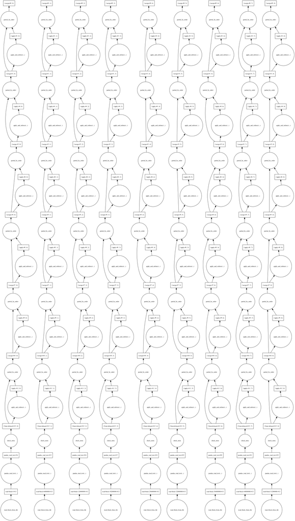

```python
full_df.visualize()
```

Below we perform execute all column merge and column drop operations that we have queued so far. We store the resulting `DataFrame` in a new variable.

```python
if 'hurricanes_merged' not in os.listdir(data_dir):
    os.mkdir(os.path.join(data_dir,'hurricanes_merged'))

merged_csv_path = os.path.join(data_dir, 'hurricanes_merged')
```

```python
%%time
merged_df = full_df.drop(columns_to_drop, axis=1)
merged_df.to_csv(os.path.join(merged_csv_path, 'hurr_dask_*.csv'))
```

```
CPU times: user 43min 46s, sys: 6min 3s, total: 49min 49s
Wall time: 45min 45s
```

The `save()` operation spawns several workers that compute in parallel. Notice the ouput file name contains a wildcard (`*`). This allows Dask to both read data in chunks and write outputs in chunks. The save operation will result in creating a number of processed CSV files whose names are prefixed with `hurr_dask` and suffixed with a number.

### Preview results

Once Dask realizes a delayed computation, it returns the result as an in-memory Pandas DataFrame object. Thus, the `merged_df` variable represents a Pandas `DataFrame` object with `348,703` records and `17` columns.

```python
merged_df.shape
```

```
(348703, 17)
```

# Creating hurricane tracks using Geoanalytics

The DASK process merged redundant columns together and ouput a folder full of CSV files. The GeoAnalytics server is also capabale of accepting a folder of datasets as 1 dataset and working on them. Thus in this part, we register that folder as a **datastore** and on the GeoAnalytics server for processing.

**Reconstruct tracks**: Reconstruct tracks is a type of data aggregation tool available in the `arcgis.geoanalytics` module. This tool works with a layer of point features or polygon features that are time enabled. It first determines which points belong to a track using an identification number or identification string. Using the time at each location, the tracks are ordered sequentially and transformed into a line representing the path of movement. The map below shows a subset of the point datasets.

[figure not shown]

## Create a data store

For the GeoAnalytics server to process your big data, it needs the data to be registered as a data store. In our case, the data is in multiple CSV files and we will register the folder containing the files as a data store of type `bigDataFileShare`.

Let us connect to an ArcGIS Enterprise

```python
gis = GIS("home")
```

Get the geoanalytics datastores and search it for the registered datasets:

```python
# Query the data stores available
datastores = get_datastores()
bigdata_fileshares = datastores.search()
bigdata_fileshares
```

```
[<Datastore title:"/enterpriseDatabases/AGSDataStore_ds_41yu9aqv" type:"egdb">,
 <Datastore title:"/bigDataFileShares/hurricanes_dask_csv" type:"bigDataFileShare">,
 <Datastore title:"/nosqlDatabases/AGSDataStore_nosqldb_tcs_yjayxzc4" type:"nosql">,
 <Datastore title:"/nosqlDatabases/AGSDataStore_bigdata_bds_wuqp7mbg" type:"nosql">,
 <Datastore title:"/rasterStores/LocalRasterDS" type:"rasterStore">]
```

The dataset `hurricanes_dask_csv` data is registered as a big data file share with the Geoanalytics datastore, so we can reference it:

```python
data_item = bigdata_fileshares[1]
```

If there is no big data file share for hurricane track data registered on the server, we can register one that points to the shared folder containing the CSV files.

```
data_item = datastores.add_bigdata("Hurricane_tracks", r"\\path_to_hurricane_data")
```

Once a big data file share is registered, the GeoAnalytics server processes all the valid file types to discern the schema of the data, including information about the geometry in a dataset. If the dataset is time-enabled, as is required to use some GeoAnalytics Tools, the manifest reports the necessary metadata about how time information is stored as well.

This process can take a few minutes depending on the size of your data. Once processed, querying the manifest property will return a schema. As you can see from below, the schema is contains the columns we merged using DASK previously.

```python
datasets = data_item.manifest['datasets']
len(datasets)
```

```
1
```

```python
[dataset['name'] for dataset in datasets]
```

```
['hurricanes_merged']
```

```python
datasets[0]
```

```
{'name': 'hurricanes_merged',
 'format': {'quoteChar': '"',
  'fieldDelimiter': ',',
  'hasHeaderRow': True,
  'encoding': 'UTF-8',
  'escapeChar': '"',
  'recordTerminator': '\n',
  'type': 'delimited',
  'extension': 'csv'},
 'schema': {'fields': [{'name': 'col_1', 'type': 'esriFieldTypeBigInteger'},
   {'name': 'Serial_Num', 'type': 'esriFieldTypeString'},
   {'name': 'Season', 'type': 'esriFieldTypeBigInteger'},
   {'name': 'Num', 'type': 'esriFieldTypeBigInteger'},
   {'name': 'Basin', 'type': 'esriFieldTypeString'},
   {'name': 'Sub_basin', 'type': 'esriFieldTypeString'},
   {'name': 'Name', 'type': 'esriFieldTypeString'},
   {'name': 'ISO_time', 'type': 'esriFieldTypeString'},
   {'name': 'Nature', 'type': 'esriFieldTypeString'},
   {'name': 'Center', 'type': 'esriFieldTypeString'},
   {'name': 'Track_type', 'type': 'esriFieldTypeString'},
   {'name': 'Current Basin', 'type': 'esriFieldTypeString'},
   {'name': 'latitude_merged', 'type': 'esriFieldTypeDouble'},
   {'name': 'longitude_merged', 'type': 'esriFieldTypeDouble'},
   {'name': 'wind_merged', 'type': 'esriFieldTypeDouble'},
   {'name': 'pressure_merged', 'type': 'esriFieldTypeDouble'},
   {'name': 'grade_merged', 'type': 'esriFieldTypeDouble'},
   {'name': 'eye_dia_merged', 'type': 'esriFieldTypeDouble'}]},
 'geometry': {'geometryType': 'esriGeometryPoint',
  'spatialReference': {'wkid': 4326},
  'fields': [{'name': 'longitude_merged', 'formats': ['x']},
   {'name': 'latitude_merged', 'formats': ['y']}]},
 'time': {'timeType': 'instant',
  'fields': [{'name': 'ISO_time', 'formats': ['yyyy-MM-dd HH:mm:ss']}],
  'timeReference': {'timeZone': 'UTC'}}}
```

## Perform data aggregation using reconstruct tracks tool

When you add a big data file share, a corresponding item gets created in your GIS. You can search for it like a regular item and query its layers.

```python
search_result = gis.content.search("", item_type = "big data file share")
search_result
```

```
[<Item title:"bigDataFileShares_hurricanes_dask_csv" type:Big Data File Share owner:amani001>]
```

```python
data_item = search_result[0]
cleaned_csv = data_item.layers[0]
cleaned_csv
```

```
<Layer url:"https://datascience-arcpy.esri.com/server/rest/services/DataStoreCatalogs/bigDataFileShares_hurricanes_dask_csv/BigDataCatalogServer/hurricanes_merged">
```

### Execute reconstruct tracks tool

The `reconstruct_tracks()` function is available in the `arcgis.geoanalytics.summarize_data` module. In this example, we are using this tool to aggregate the numerous points into line segments showing the tracks followed by the hurricanes. The tool creates a feature layer item as an output which can be accessed once the processing is complete.

```python
agg_result = reconstruct_tracks(cleaned_csv,
                                track_fields='Serial_Num',   # the Hurricane id number
                                method='GEODESIC', output_name='hurricane_tracks_aggregated_ga')
```

```
Submitted.
Executing...
Executing (ReconstructTracks): ReconstructTracks "Feature Set" Serial_Num Geodesic # # # # # # "{"serviceProperties": {"name": "hurricane_tracks_aggregated_ga", "serviceUrl": "https://datascience-arcpy.esri.com/server/rest/services/Hosted/hurricane_tracks_aggregated_ga/FeatureServer"}, "itemProperti…
Start Time: Thu Nov 15 21:57:30 2018
Using URL based GPRecordSet param: https://datascience-arcpy.esri.com/server/rest/services/DataStoreCatalogs/bigDataFileShares_hurricanes_dask_csv/BigDataCatalogServer/hurricanes_merged
{"messageCode":"BD_101028","message":"Starting new distributed job with 352 tasks.","params":{"totalTasks":"352"}}
{"messageCode":"BD_101029","message":"0/352 distributed tasks completed.","params":{"completedTasks":"0","totalTasks":"352"}}
{"messageCode":"BD_101029","message":"177/352 distributed tasks completed.","params":{"completedTasks":"177","totalTasks":"352"}}
{"messageCode":"BD_101029","message":"241/352 distributed tasks completed.","params":{"completedTasks":"241","totalTasks":"352"}}
{"messageCode":"BD_101029","message":"308/352 distributed tasks completed.","params":{"completedTasks":"308","totalTasks":"352"}}
{"messageCode":"BD_101029","message":"352/352 distributed tasks completed.","params":{"completedTasks":"352","totalTasks":"352"}}
{"messageCode":"BD_101081","message":"Finished writing results:"}
{"messageCode":"BD_101082","message":"* Count of features = 12757","params":{"resultCount":"12757"}}
{"messageCode":"BD_101083","message":"* Spatial extent = {\"xmin\":-180,\"ymin\":-68.5,\"xmax\":180,\"ymax\":81}","params":{"extent":"{\"xmin\":-180,\"ymin\":-68.5,\"xmax\":180,\"ymax\":81}"}}
{"messageCode":"BD_101084","message":"* Temporal extent = Interval(MutableInstant(1842-10-25 06:00:00.000),MutableInstant(2017-06-13 06:00:00.000))","params":{"extent":"Interval(MutableInstant(1842-10-25 06:00:00.000),MutableInstant(2017-06-13 06:00:00.000))"}}
```

```
{"messageCode":"BD_101054","message":"Some records have either missing or invalid geometries."}
```

```
{"messageCode":"BD_101054","message":"Some records have either missing or invalid geometries."}
Succeeded at Thu Nov 15 21:57:54 2018 (Elapsed Time: 24.21 seconds)
```

### Analyze the result of aggregation

```python
agg_tracks_layer = agg_result.layers[0]
agg_fields = [f.name for f in agg_tracks_layer.properties.fields]
pprint(agg_fields, compact=True)
```

```
['Serial_Num', 'COUNT', 'COUNT_col_1', 'SUM_col_1', 'MIN_col_1', 'MAX_col_1',
 'MEAN_col_1', 'RANGE_col_1', 'SD_col_1', 'VAR_col_1', 'COUNT_Season',
 'SUM_Season', 'MIN_Season', 'MAX_Season', 'MEAN_Season', 'RANGE_Season',
 'SD_Season', 'VAR_Season', 'COUNT_Num', 'SUM_Num', 'MIN_Num', 'MAX_Num',
 'MEAN_Num', 'RANGE_Num', 'SD_Num', 'VAR_Num', 'COUNT_Basin', 'ANY_Basin',
 'COUNT_Sub_basin', 'ANY_Sub_basin', 'COUNT_Name', 'ANY_Name', 'COUNT_ISO_time',
 'ANY_ISO_time', 'COUNT_Nature', 'ANY_Nature', 'COUNT_Center', 'ANY_Center',
 'COUNT_Track_type', 'ANY_Track_type', 'COUNT_Current_Basin',
 'ANY_Current_Basin', 'COUNT_latitude_merged', 'SUM_latitude_merged',
 'MIN_latitude_merged', 'MAX_latitude_merged', 'MEAN_latitude_merged',
 'RANGE_latitude_merged', 'SD_latitude_merged', 'VAR_latitude_merged',
 'COUNT_longitude_merged', 'SUM_longitude_merged', 'MIN_longitude_merged',
 'MAX_longitude_merged', 'MEAN_longitude_merged', 'RANGE_longitude_merged',
 'SD_longitude_merged', 'VAR_longitude_merged', 'COUNT_wind_merged',
 'SUM_wind_merged', 'MIN_wind_merged', 'MAX_wind_merged', 'MEAN_wind_merged',
 'RANGE_wind_merged', 'SD_wind_merged', 'VAR_wind_merged',
 'COUNT_pressure_merged', 'SUM_pressure_merged', 'MIN_pressure_merged',
 'MAX_pressure_merged', 'MEAN_pressure_merged', 'RANGE_pressure_merged',
 'SD_pressure_merged', 'VAR_pressure_merged', 'COUNT_grade_merged',
 'SUM_grade_merged', 'MIN_grade_merged', 'MAX_grade_merged',
 'MEAN_grade_merged', 'RANGE_grade_merged', 'SD_grade_merged',
 'VAR_grade_merged', 'COUNT_eye_dia_merged', 'SUM_eye_dia_merged',
 'MIN_eye_dia_merged', 'MAX_eye_dia_merged', 'MEAN_eye_dia_merged',
 'RANGE_eye_dia_merged', 'SD_eye_dia_merged', 'VAR_eye_dia_merged',
 'TRACK_DURATION', 'globalid', 'OBJECTID', 'END_DATETIME', 'START_DATETIME']
```

To get the number of hurricanes the reconstruct tracks tool identified, we run a query on the aggregation layer and get just the number of records.

```python
agg_tracks_layer.query(return_count_only=True)
```

```
12362
```

# Conclusion

In Part 2 of this study, we will visualize and explore this dataset to understand the prevelance, duration of hurricanes and the communities affected by hurricanes worldwide.

In Part 3, we will analyze this aggregated result comprehensively, answer important questions such as, does the intensity of hurricanes increase over time and draw conclusions.